# HassanYusufAfolabi_CP

## CAPSTONE PROJECT PROBLEM STATEMENT

You have been appointed as the Lead Data Analyst to build a predictive model to determine if a building will have an insurance claim during a certain period or not. You will have to predict the probability of having at least one claim over the insured period of the building. The model will be based on the building characteristics.

The target variable, Claim, is a: 1 if the building has at least a claim over the insured period. 0 if the building doesn’t have a claim over the insured period.

You have the data description and the training data too Ensure you do all the necessary data preprocessing to improve your result, and evaluate too Also, your work should be added as a project to your GitHub repository.

The link to the repository that has your notebook(s) is what is expected to be submitted.

**TO BE NOTED** A good project contains

1. A good data cleaning and preprocessing
2. A detailed and explained set of insights through Exploratory Data Analysis
3. A well-experimented preprocessing for modelling
4. Implement more than 1 model
5. Evaluate the models

| No | Variable | Description |
| --- | --- | --- |
| 1 | Customer Id Identification | number for the Policy holder |
| 2 | YearOfObservation | year of observation for the insured policy |
| 3 | Insured_Period | duration of insurance policy in Olusola Insurance. |
|  |  | (Ex: Full year insurance, Policy Duration =1; 6 months = 0.5 |
| 4 | Residential is the building | a residential building or not |
| 5 | Building_Painted | is the building painted or not (N-Painted, V-Not Painted) |
| 6 | Building_Fenced | is the building fence or not (N-Fenced, V-Not Fenced) |
| 7 | Garden building has garden or not | (V-has garden; O-no garden) |
| 8 | Settlement Area where the building is located. | (R- rural area; U- urban area) |
| 9 | Building Dimension | Size of the insured building in m2 |
| 10 | Building_Type | The type of building (Type 1, 2, 3, 4) |
| 11 | Date_of_Occupancy | date building was first occupied |
| 12 | NumberOfWindows | number of windows in the building |
| 13 | Geo Code | Geographical Code of the Insured building |
| 14 | Claim target variable. | (0: no claim, 1: at least one claim over insured period). |

**Objective:** Predict the probability that a building will experience at least one insurance claim during the insured period using building characteristics.

Target Variable:

Claim = 1: At least one claim

Claim = 0: No claim

```python
import pandas as pd
import numpy as np
import matplotlib.pyplot as plt
import seaborn as sns
from scipy import stats
from mpl_toolkits.mplot3d import Axes3D
from sklearn.inspection import permutation_importance
from sklearn.ensemble import IsolationForest
from sklearn.neighbors import LocalOutlierFactor
from sklearn.linear_model import LogisticRegression
from sklearn.ensemble import RandomForestClassifier
from sklearn.preprocessing import StandardScaler
from sklearn.pipeline import Pipeline
from sklearn.metrics import roc_curve
from sklearn.metrics import precision_recall_curve
from sklearn.model_selection import cross_val_score
from sklearn.model_selection import train_test_split, RandomizedSearchCV
from sklearn.metrics import accuracy_score, roc_auc_score, classification_report,confusion_matrix
```

```python
#Data Loading & Raw Data Preservation

# To load the data
df = pd.read_csv("Train_data.csv")

#The logic here is to Create a Backup Before Cleaning
# IMPORTANT: preserve raw data
df_raw = df.copy()
```

```python
# The first few rows (instances) data evaluation
# df.head()
df.head()
```

|  | Customer Id | YearOfObservation | Insured_Period | Residential | Building_Painted | Building_Fenced | Garden | Settlement | Building Dimension | Building_Type | Date_of_Occupancy | NumberOfWindows | Geo_Code | Claim |
| --- | --- | --- | --- | --- | --- | --- | --- | --- | --- | --- | --- | --- | --- | --- |
| 0 | H14663 | 2013 | 1.0 | 0 | N | V | V | U | 290.0 | 1 | 1960.0 | . | 1053 | 0 |
| 1 | H2037 | 2015 | 1.0 | 0 | V | N | O | R | 490.0 | 1 | 1850.0 | 4 | 1053 | 0 |
| 2 | H3802 | 2014 | 1.0 | 0 | N | V | V | U | 595.0 | 1 | 1960.0 | . | 1053 | 0 |
| 3 | H3834 | 2013 | 1.0 | 0 | V | V | V | U | 2840.0 | 1 | 1960.0 | . | 1053 | 0 |
| 4 | H5053 | 2014 | 1.0 | 0 | V | N | O | R | 680.0 | 1 | 1800.0 | 3 | 1053 | 0 |

```python
#  The last few rows (instances)data evaluation
df.tail()
```

|  | Customer Id | YearOfObservation | Insured_Period | Residential | Building_Painted | Building_Fenced | Garden | Settlement | Building Dimension | Building_Type | Date_of_Occupancy | NumberOfWindows | Geo_Code | Claim |
| --- | --- | --- | --- | --- | --- | --- | --- | --- | --- | --- | --- | --- | --- | --- |
| 7155 | H5290 | 2012 | 1.000000 | 1 | V | V | V | U | NaN | 1 | 2001.0 | . | NaN | 0 |
| 7156 | H5926 | 2013 | 1.000000 | 0 | V | V | V | U | NaN | 2 | 1980.0 | . | NaN | 1 |
| 7157 | H6204 | 2016 | 0.038251 | 0 | V | V | V | U | NaN | 1 | 1992.0 | . | NaN | 0 |
| 7158 | H6537 | 2013 | 1.000000 | 0 | V | V | V | U | NaN | 1 | 1972.0 | . | NaN | 0 |
| 7159 | H7470 | 2014 | 1.000000 | 0 | V | V | V | U | NaN | 1 | 2004.0 | . | NaN | 0 |

```python
df.shape
```

```
(7160, 14)
```

```python
#To Confirm data size and possible types
df.info()
```

```
<class 'pandas.core.frame.DataFrame'>
RangeIndex: 7160 entries, 0 to 7159
Data columns (total 14 columns):
 #   Column              Non-Null Count  Dtype
---  ------              --------------  -----
 0   Customer Id         7160 non-null   object
 1   YearOfObservation   7160 non-null   int64
 2   Insured_Period      7160 non-null   float64
 3   Residential         7160 non-null   int64
 4   Building_Painted    7160 non-null   object
 5   Building_Fenced     7160 non-null   object
 6   Garden              7153 non-null   object
 7   Settlement          7160 non-null   object
 8   Building Dimension  7054 non-null   float64
 9   Building_Type       7160 non-null   int64
 10  Date_of_Occupancy   6652 non-null   float64
 11  NumberOfWindows     7160 non-null   object
 12  Geo_Code            7058 non-null   object
 13  Claim               7160 non-null   int64
dtypes: float64(3), int64(4), object(7)
memory usage: 783.3+ KB
```

```python
# DUPLICATES HANDLING;
# To view if evident
duplicates = df[df.duplicated()]
print("\n Duplicate rows preview:")
print(duplicates.head())

# Count of duplicates
duplicate_count = df.duplicated().sum()
print(f"Number of duplicate rows: {duplicate_count}")
```

```
 Duplicate rows preview:
Empty DataFrame
Columns: [Customer Id, YearOfObservation, Insured_Period, Residential, Building_Painted, Building_Fenced, Garden, Settlement, Building Dimension, Building_Type, Date_of_Occupancy, NumberOfWindows, Geo_Code, Claim]
Index: []
Number of duplicate rows: 0
```

**Duplicate rows preview:** No Duplicate Evident

```python
#To Identify missing values if any
df.isnull().sum()
```

```
Customer Id             0
YearOfObservation       0
Insured_Period          0
Residential             0
Building_Painted        0
Building_Fenced         0
Garden                  7
Settlement              0
Building Dimension    106
Building_Type           0
Date_of_Occupancy     508
NumberOfWindows         0
Geo_Code              102
Claim                   0
dtype: int64
```

*To be Noted ;* Missing Values thus seem to exist

```python
print(df.columns.tolist())
```

```
['Customer Id', 'YearOfObservation', 'Insured_Period', 'Residential', 'Building_Painted', 'Building_Fenced', 'Garden', 'Settlement', 'Building Dimension', 'Building_Type', 'Date_of_Occupancy', 'NumberOfWindows', 'Geo_Code', 'Claim']
```

```python
#For Statistical Summary (Numerical Understanding)
#Understand distributions

#To Spot anomalies

#To Check ranges
df.describe()
```

|  | YearOfObservation | Insured_Period | Residential | Building Dimension | Building_Type | Date_of_Occupancy | Claim |
| --- | --- | --- | --- | --- | --- | --- | --- |
| count | 7160.000000 | 7160.000000 | 7160.000000 | 7054.000000 | 7160.000000 | 6652.000000 | 7160.000000 |
| mean | 2013.669553 | 0.909758 | 0.305447 | 1883.727530 | 2.186034 | 1964.456404 | 0.228212 |
| std | 1.383769 | 0.239756 | 0.460629 | 2278.157745 | 0.940632 | 36.002014 | 0.419709 |
| min | 2012.000000 | 0.000000 | 0.000000 | 1.000000 | 1.000000 | 1545.000000 | 0.000000 |
| 25% | 2012.000000 | 0.997268 | 0.000000 | 528.000000 | 2.000000 | 1960.000000 | 0.000000 |
| 50% | 2013.000000 | 1.000000 | 0.000000 | 1083.000000 | 2.000000 | 1970.000000 | 0.000000 |
| 75% | 2015.000000 | 1.000000 | 1.000000 | 2289.750000 | 3.000000 | 1980.000000 | 0.000000 |
| max | 2016.000000 | 1.000000 | 1.000000 | 20940.000000 | 4.000000 | 2016.000000 | 1.000000 |

**EXPLORATORY DATA ANANLYSIS EDA** statistical interpretation of df.describe() aligned with the three main objective goals:

- To Understand distributions
- To Spot anomalies
- To Check for ranges

Statistical Summary & Numerical Insights

The statistical summary provides insight into the central tendency, dispersion, and range of numerical features, helping identify potential anomalies and data quality issues.

**A,** YearOfObservation

| Metric | Value |
| --- | --- |
| Min – Max | 2012 – 2016 |
| Mean | 2013.67 |
| Std Dev | 1.38 |

*Observational Interpretation*

Data spans 5 years, indicating temporal stability.

Narrow range = no anomalies.

Feature is reliable and suitable for modeling.

**B,** Insured_Period

| Metric | Value |
| --- | --- |
| Min | 0.0 |
| Max | 1.0 |
| Mean | 0.91 |
| Std Dev | 0.24 |

*Observational Interpretation*

Majority of policies are full-year contracts.

Minimum value of 0.0 is a potential anomaly:

Could represent policies canceled immediately or data entry issues.

Retained because short policy duration is logically meaningful for claim risk.

- Feasible Action: Keep feature, monitor low-duration policies.

**C,** Residential

| Metric | Value |
| --- | --- |
| Mean | 0.31 |

*Observational Interpretation*

~31% of buildings are residential.

whil Binary distribution appears to be balanced enough for modeling.

No anomalies detected.

**D,** Building Dimension (Size in m²)

| Metric | Value |
| --- | --- |
| Min | 1 m² |
| Max | 20,940 m² |
| Mean | 1,884 m² |
| Std Dev | 2,278 m² |

*Observational Interpretation*

Highly right-skewed distribution.

Very small buildings (1 m²) and extremely large buildings suggest outliers.

Wide dispersion indicates high variance in building sizes.

*Feasible Action To Taken:

Missing values imputed with median.

Model choice Could be Random Forest because it thus handles skewness well.

Optional log transformation could be applied if using linear models.

**E,** Building_Type

| Metric | Value |
| --- | --- |
| Range | 1 – 4 |
| Mean | 2.19 |

*Observational Interpretation*

Categorical variable encoded numerically.

No invalid values detected.

Could be Safe for one-hot encoding.

**F,** Date_of_Occupancy

| Metric | Value |
| --- | --- |
| Min | 1545 |
| Max | 2016 |
| Mean | 1964 |

*Observational Interpretation*

Minimum value 1545 is historically unrealistic.

Suggests data entry errors or placeholder values.

Direct usage may distort modeling.

- Feasible Action to be taken:

Converte to Building Age feature.

Median imputation applied to missing values.

**G,** Claim (Target Variable)

| Metric | Value |
| --- | --- |
| Mean | 0.228 |
| Positive Class | ~22.8% |

*Observational Interpretation*

Dataset is moderately imbalanced.

Claims are the minority class (~1:3.4 ratio).

- Feasible Action to be taken

class_weight='balanced' could be utilized later

Model evaluation could require using ROC-AUC instead of accuracy only

**H,** Key EDA Summary Conclusions

- No severe data leakage
- Some extreme outliers in building size
- Invalid historical values in occupancy year
- Class imbalance present but manageable
- Feature engineering (Building Age) justified

**I,** Business Insight

Claim occurrence is not random as patterns thus exist.

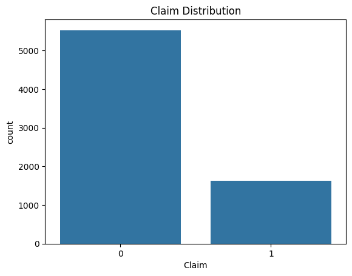

```python
sns.countplot(x='Claim', data=df)
plt.title('Claim Distribution')
plt.show()
```

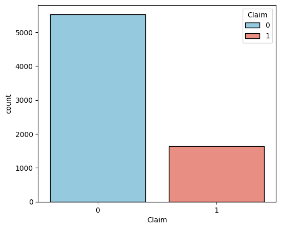

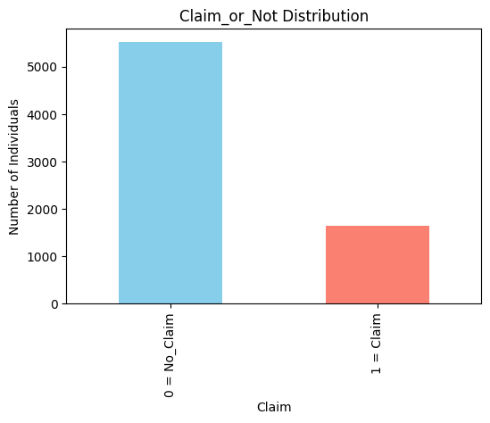

```python
plt.figure(figsize=(6, 5))
sns.countplot(x='Claim', data=df, hue='Claim', palette=['skyblue', 'salmon'], edgecolor='black')
legend=False

# Customized labels
plt.figure(figsize=(6,4))
df['Claim'].value_counts().plot(kind='bar', color=['skyblue', 'salmon'])
plt.xticks([0, 1], ['0 = No_Claim', '1 = Claim'])
plt.title('Claim_or_Not Distribution')
plt.ylabel('Number of Individuals')
plt.show()
```

```python
#To Target Variable Check (VERY IMPORTANT)

#Purpose

#To Confirm class imbalance

#To further help Decide modeling strategy later
```

```python
#To Target Variable Check (VERY IMPORTANT)
#Confirm class imbalance
#To Help Decide modeling strategy later
df['Claim'].value_counts(normalize=True) * 100
```

```
Claim
0    77.178771
1    22.821229
Name: proportion, dtype: float64
```

```python
df['Claim'].value_counts(normalize=True)
```

```
Claim
0    0.771788
1    0.228212
Name: proportion, dtype: float64
```

```python
print(df['Claim'].value_counts())
```

```
Claim
0    5526
1    1634
Name: count, dtype: int64
```

These Confirms class imbalance (~23% claims)

```python
# Data Preprocessing & Feature Engineering
# To Drop Non-Predictive Feature
df = df.drop(columns=['Customer Id'])
```

# This "." represents missing values.

df['NumberOfWindows'] = df['NumberOfWindows'].replace('.', np.nan) df['NumberOfWindows'] = df['NumberOfWindows'].astype(float) df['NumberOfWindows'].fillna(df['NumberOfWindows'].median(), inplace=True) Error Result Ecountered;

The column NumberOfWindows does not only contain "." It also contains values like: ' .' ValueError: could not convert string to float: ' .'

That implies that, their seems to be:

Leading spaces

Non-numeric characters

Therefore Pandas could not convert these to float directly

So .astype(float) fails.

```python
#Data Cleaning & Missing Value Handling
#To Fix NumberOfWindows

# This should help handle:

# "."

# " ."

# Empty strings

# Any unexpected garbage values

# To Clean NumberOfWindows properly
df['NumberOfWindows'] = (
    df['NumberOfWindows']
    .astype(str)           # ensure string
    .str.strip()           # remove spaces
    .replace('.', np.nan)  # replace dot
)

# To help Convert safely
df['NumberOfWindows'] = pd.to_numeric(
    df['NumberOfWindows'], errors='coerce'
)

# To Impute missing values
df['NumberOfWindows'].fillna(
    df['NumberOfWindows'].median(), inplace=True
)
```

```python
#This is to help Verify the Fix made

df['NumberOfWindows'].dtype
df['NumberOfWindows'].isnull().sum()
df['NumberOfWindows'].describe()
```

```
count    7160.000000
mean        4.111453
std         1.165521
min         1.000000
25%         4.000000
50%         4.000000
75%         4.000000
max         9.000000
Name: NumberOfWindows, dtype: float64
```

The cleaning was successful:

NumberOfWindows is now float64

with 0 missing values

Clean, realistic range:

Stat Value Min 1 Max 9 Median 4 Mean 4.11

This distribution now seems to make real-world sense

**LOGIC BEHIND ALTERNATIV OPTIONS**

| Method | Result |
| --- | --- |
| .astype(float) | could be brittle |
| pd.to_numeric(errors='coerce') | seem more robust |
| .str.strip() | help handles dirty strings |
| Median imputation | resistant to outliers |

**TO BE NOTED** The NumberOfWindows variable contained non-numeric placeholders such as "." and values with leading spaces. These were cleaned by stripping whitespace and coercing invalid entries to NaN, followed by median imputation to preserve distribution robustness.

```python
#To Handle Remaining Missing Values (NO inplace)

# Numerical Features
df['Building Dimension'] = df['Building Dimension'].fillna(
    df['Building Dimension'].median()
)

df['Date_of_Occupancy'] = df['Date_of_Occupancy'].fillna(
    df['Date_of_Occupancy'].median()
)
# Categorical Features
df['Garden'] = df['Garden'].fillna(df['Garden'].mode()[0])
df['Geo_Code'] = df['Geo_Code'].fillna(df['Geo_Code'].mode()[0])
```

```python
# To Validate
df.isnull().sum()
```

```
YearOfObservation     0
Insured_Period        0
Residential           0
Building_Painted      0
Building_Fenced       0
Garden                0
Settlement            0
Building Dimension    0
Building_Type         0
Date_of_Occupancy     0
NumberOfWindows       0
Geo_Code              0
Claim                 0
dtype: int64
```

```python
# Proof That Assignment Is Permanent
# When inplace=True Is Being Removed
df['Building Dimension'] = df['Building Dimension'].fillna(
    df['Building Dimension'].median()
)

df.isnull().sum()
```

```
YearOfObservation     0
Insured_Period        0
Residential           0
Building_Painted      0
Building_Fenced       0
Garden                0
Settlement            0
Building Dimension    0
Building_Type         0
Date_of_Occupancy     0
NumberOfWindows       0
Geo_Code              0
Claim                 0
dtype: int64
```

```python
#The change persisted without inplace=True.
```

**Decision Logic** Missing values in numerical variables were imputed using the median to mitigate the impact of skewness and outliers. Categorical variables were imputed using the mode. Assignment-based imputation was used to avoid chained assignment and ensure compatibility with future versions of pandas.

THEREFORE; Assignment-based transformations were used instead of inplace operations to ensure explicit, permanent updates and compatibility with future pandas versions.

```python
#This is to enable the  Scan Of ALL Columns for Hidden “Dirty” Values
#Universal Dirty-Value Scanner (Safe & Reusable)
#Hidden dirty values usually include:
#Extra spaces (' V')
#Placeholder symbols ('.', '?', 'NA')
#Mixed types inside object columns
#Unexpected unique values
for col in df.columns:
    if df[col].dtype == 'object':
        print(f"\nColumn: {col}")
        print("Unique values (sample):", df[col].unique()[:10])
```

```
Column: Building_Painted
Unique values (sample): ['N' 'V']

Column: Building_Fenced
Unique values (sample): ['V' 'N']

Column: Garden
Unique values (sample): ['V' 'O']

Column: Settlement
Unique values (sample): ['U' 'R']

Column: Geo_Code
Unique values (sample): ['1053' '1143' '1160' '1173' '1224' '1283' '1305' '1363' '1419' '2059']
```

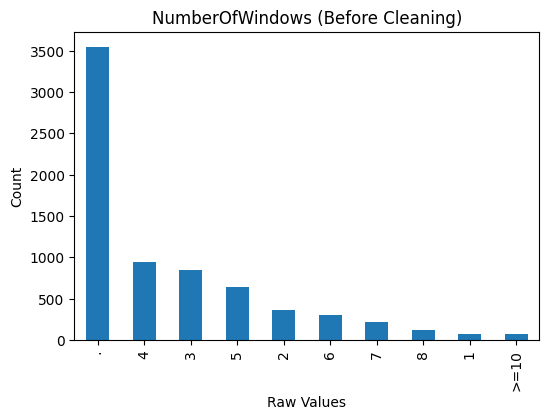

```python
# This is To Plot BEFORE vs AFTER Cleaning (NumberOfWindows)

# This visually assertain the impact of cleaning, .

raw_windows = df_original['NumberOfWindows'].astype(str)

plt.figure(figsize=(6,4))
raw_windows.value_counts().head(10).plot(kind='bar')
plt.title("NumberOfWindows (Before Cleaning)")
plt.xlabel("Raw Values")
plt.ylabel("Count")
plt.show()
```

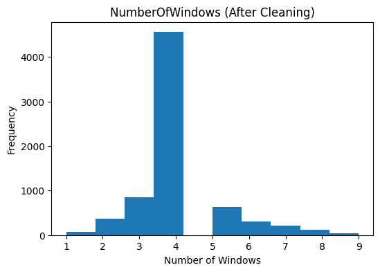

```python
#AFTER Cleaning (Final Feature)
plt.figure(figsize=(6,4))
df['NumberOfWindows'].plot(kind='hist', bins=10)
plt.title("NumberOfWindows (After Cleaning)")
plt.xlabel("Number of Windows")
plt.ylabel("Frequency")
plt.show()
```

*IT SHOULD BE NOTED THAT;* A copy of the original dataset was preserved prior to preprocessing to allow visual comparison of feature distributions before and after cleaning.

```python
#To execute Feature Engineering
#Building Age (Critical Feature)
#Create Building Age (more predictive than raw occupancy year).
#It help Removes unrealistic historical values (e.g. 1545)

df['Building_Age'] = df['YearOfObservation'] - df['Date_of_Occupancy']
df.drop(columns=['Date_of_Occupancy'], inplace=True)
```

```python
#To Encode Categorical Variables
binary_map = {
    'V': 1, 'N': 0,
    'O': 0,
    'R': 0, 'U': 1
}

for col in ['Building_Painted','Building_Fenced','Garden','Settlement']:
    df[col] = df[col].map(binary_map)
```

**The Business meaning**

Painted / Fenced / Garden = risk mitigation